# **Introduction to Statistical Modeling in `R`**

BCAM - Basque Center for Applied Mathematics, Applied Statistics

Dae-Jin Lee < dlee@bcamath.org >

BCAM/UPV-EHU Courses 2016-2017

This course is an introduction to statistical software `R`. The course will introduce the student to the basics of using `R` for statistical programming, computation, graphics, and basic statistical modeling.

This course is oriented to undergraduate and Master students, or any researcher interested in learning the statistical software `R`.

**Objectives:**

- Use `R` for basic data analysis.
- Write functions in and use `R` in efficient way,
- Perform basic statistical analysis and basic statistical models.

**Pre-requisites:**

There are no formal prerequisites, but some basic knowledge of statistics is expected. The intended audience is anyone who needs a flexible statistical environment for their research. Any prior knowledge of `R` is not expected.

**Compulsory:**

- Bring your laptop with the latest version of `R` installed. Download it [here](https://cran.r-project.org/)
- Rstudio is a user-friendly interface. Download it [here](https://www.rstudio.com/products/rstudio/download/) **Highly recommended!!!**
- Internet connection to download the material and install some packages.

# 1 Introduction to the `R` language

- `R` is a free software environment for statistical computing and graphics http://www.r-project.org
- `R` is a command-driven statistical package.
- The most important reasons to use `R` are:
  - `R` is free and multiplatform (Windows/Linux/MACos)
  - `R` allows you to do all the statistical tests/models/analysis you need :)
  - Excellent graphics and programming capabilities
  - Growing community of users and developers
  - Lots of online resources
- Statistical features:
  - Graphical Techniques (Exploratory Data Analysis)
  - Linear and non-linear modeling (linear regression, non-parametric regression, smoothing, etc …)
  - Classical statistical tests
  - Time-series analysis
  - Econometrics
  - Survival analysis
  - Classification and clustering (data mining, machine learning)
  - Optimization and Mathematical Programming
  - Bayesian inference etc ….

**Visit** http://cran.r-project.org/web/views or http://stackoverflow.com/questions/tagged/r

## 1.1 Start with `R`

- Get current working directory

```r
getwd()
```

- Set working directory

```r
setwd("/Users/dlee")
```

## 1.2 Install and load an `R` library

```r
install.packages("DAAG") # (Data Analysis And Graphics)
```

- Once installed the package, load it

```r
library(DAAG) # or require(DAAG)
```

## 1.3 Reading data

The `R` console

```r
x <- c(7.82,8.00,7.95) # c means "combine"
x
```

```
## [1] 7.82 8.00 7.95
```

A quicker way is to use `scan()`

```r
x <- scan()  # enter a number followed by return and blank line to end
1: 7.82
2: 8.00
3: 7.95
4:
Read 3 items
```

To create a character vector use `""`

```r
id <- c("John","Paul","George","Ringo")
```

To read a character vector

```r
id <- scan(,"")
1: John
2: Paul
3: George
4: Ringo
5:
Read 4 items
```

```r
id
```

```
## [1] "John"   "Paul"   "George" "Ringo"
```

## 1.4 Data Import

In most situations, we need to read data from a separate data file. There are several methods for doing this.

- `scan()` (see `?scan` for help)

```r
cat("Example:", "2 3 5 7", "11 13 17", file = "ex.txt", sep = "\n") # creates ex.txt
pp <- scan("ex.txt", skip = 1, quiet = TRUE)
scan("ex.txt", skip = 1)
```

```
## [1]  2  3  5  7 11 13 17
```

```r
scan("ex.txt", skip = 1, nlines = 1) # only 1 line after the skipped one
```

```
## [1] 2 3 5 7
```

```r
unlink("ex.data") # tidy up
```

- Several formats are available (`.txt`, `.csv`, `.xls`, `.xlsx`, `SAS`, `Stata`, etc…)
- Some `R` libraries to import data are

```r
library(gdata)
library(foreign)
```

- Read data from a `.txt` or `.csv` files (*e.g.:* created in `Rintro1.R`)

```r
mydata1 = read.table("cardata.txt")
mydata2 = read.csv("cardata.csv")
```

- Other formats `.xls` and `.xlsx`

```r
# read in the worksheet named mysheet
mydata <- read.xlsx("myexcel.xlsx", sheetName = "mysheet")
```

- Minitab, SPSS, SAS or Stata

```r
library(foreign)
mydata = read.mtp("mydata.mtp")  # Minitab
mydata = read.spss("myfile", to.data.frame=TRUE) # SPSS
mydata = read.dta("mydata.dta") # Stata
```

- Or

```r
library(Hmisc)
mydata = spss.get("mydata.por", use.value.labels=TRUE)  # SPSS
```

## 1.5 Exporting data

- There are numerous methods for exporting `R` objects into other formats . For SPSS, SAS and Stata. you will need to load the `foreign` packages. For Excel, you will need the `xlsx` package.
- Tab delimited text file

```r
write.table(mydata, "mydata.txt", sep="\t")
```

- Excel spreadsheet

```r
library(xlsx)
write.xlsx(mydata, "mydata.xlsx")
```

## 1.6 Data vectors

- Download `R code` [here](http://idaejin.github.io/bcam-courses/rbasics/rbasics.R)
- Create a vector of weights and heights

```r
weight<-c(60,72,57,90,95,72)
class(weight)
```

```
## [1] "numeric"
```

```r
height<-c(1.75,1.80,1.65,1.90,1.74,1.91)
```

- calculate Body Mass Index

```r
bmi<- weight/height^2
bmi
```

```
## [1] 19.59184 22.22222 20.93664 24.93075 31.37799 19.73630
```

## 1.7 Basic statistics

- mean, median, st dev, variance

```r
mean(weight)
median(weight)
sd(weight)
var(weight)
```

- summarize data

```r
summary(weight)
```

```
##    Min. 1st Qu.  Median    Mean 3rd Qu.    Max.
##   57.00   63.00   72.00   74.33   85.50   95.00
```

- or

```r
min(weight)
max(weight)
range(weight)
quantile(weight)
sum(weight)
length(weight)
```

## 1.8 Character vectors and factor variables

```r
subject <- c("John","Peter","Chris","Tony","Mary","Jane")
sex <- c("MALE","MALE","MALE","MALE","FEMALE","FEMALE")
class(subject)
```

```
## [1] "character"
```

```r
table(sex)
```

```
## sex
## FEMALE   MALE
##      2      4
```

## 1.9 Data frames

```r
Dat <- data.frame(subject,sex,weight,height)
# add bmi to Dat
Dat$bmi <- bmi  # or Dat$bmi <- weight/height^2
class(Dat)
```

```
## [1] "data.frame"
```

```r
str(Dat) # display object structure
```

```
## 'data.frame':    6 obs. of  5 variables:
##  $ subject: Factor w/ 6 levels "Chris","Jane",..: 3 5 1 6 4 2
##  $ sex    : Factor w/ 2 levels "FEMALE","MALE": 2 2 2 2 1 1
##  $ weight : num  60 72 57 90 95 72
##  $ height : num  1.75 1.8 1.65 1.9 1.74 1.91
##  $ bmi    : num  19.6 22.2 20.9 24.9 31.4 ...
```

```r
# Change rownames
rownames(Dat)<-c("A","B","C","D","E","F")

# Access to data frame elements (similar to a matrix)
Dat[,1]     # 1st column
```

```
## [1] John  Peter Chris Tony  Mary  Jane
## Levels: Chris Jane John Mary Peter Tony
```

```r
Dat[,1:3]   # 1st to 3rd columns
```

```
##   subject    sex weight
## A    John   MALE     60
## B   Peter   MALE     72
## C   Chris   MALE     57
## D    Tony   MALE     90
## E    Mary FEMALE     95
## F    Jane FEMALE     72
```

```r
Dat[1:2,]   # 1st to 2nd row
```

```
##   subject  sex weight height      bmi
## A    John MALE     60   1.75 19.59184
## B   Peter MALE     72   1.80 22.22222
```

## 1.10 Working with data frames

**Example: Analyze data by groups**

- Obtain the mean weight, heigth and bmi means by FEMALES and MALES:
1. Select each group and compute the mean

```r
Dat[sex=="MALE",]
Dat[sex=="FEMALE",]

mean(Dat[sex=="MALE",3])  # weight average of MALEs
mean(Dat[sex=="MALE","weight"])
```

2. Use `apply` by columns

```r
apply(Dat[sex=="FEMALE",3:5],2,mean)
apply(Dat[sex=="MALE",3:5],2,mean)

# we can use apply with our own function
apply(Dat[sex=="FEMALE",3:5],2,function(x){x+2})
```

3. `by` and `colMeans`

```r
by(Dat[,3:5],sex, colMeans) # 'by' splits your data by factors and do calculations on each subset.
```

4. `aggregate`

```r
# another option
aggregate(Dat[,3:5], by=list(sex),mean)
```

## 1.11 Logical vectors

- Choose individuals with BMI>22

```r
bmi
bmi>22
as.numeric(bmi>22) # convert a logical condition to a numeric value 0/1
which(bmi>22)  # gives the position of bmi for which bmi>22
```

- Which are between 20 and 25?

```r
bmi > 20 & bmi < 25
which(bmi > 20 & bmi < 25)
```

## 1.12 Working with vectors

- Concatenate

```r
x <- c(2, 3, 5, 2, 7, 1)
y <- c(10, 15, 12)
z <- c(x,y)  # concatenates x and y
```

- list two vectors

```r
zz <- list(x,y) # create a list
unlist(zz) # unlist the list converting it to a concatenated vector
```

```
## [1]  2  3  5  2  7  1 10 15 12
```

- subset of vectors

```r
x[c(1,3,4)]
```

```
## [1] 2 5 2
```

```r
x[-c(2,6)] # negative subscripts omit the chosen elements
```

```
## [1] 2 5 2 7
```

- Sequences

```r
seq(1,9) # or 1:9
```

```
## [1] 1 2 3 4 5 6 7 8 9
```

```r
seq(1,9,by=1)
```

```
## [1] 1 2 3 4 5 6 7 8 9
```

```r
seq(1,9,by=0.5)
```

```
##  [1] 1.0 1.5 2.0 2.5 3.0 3.5 4.0 4.5 5.0 5.5 6.0 6.5 7.0 7.5 8.0 8.5 9.0
```

```r
seq(1,9,length=20)
```

```
##  [1] 1.000000 1.421053 1.842105 2.263158 2.684211 3.105263 3.526316
##  [8] 3.947368 4.368421 4.789474 5.210526 5.631579 6.052632 6.473684
## [15] 6.894737 7.315789 7.736842 8.157895 8.578947 9.000000
```

- Replicates

```r
oops <- c(7,9,13)
rep(oops,3) # repeats the entire vector "oops" three times
rep(oops,1:3) # this function has the number 3 replaced
              #  by a vector with the three values (1,2,3)
              #  indicating that 7 should be repeated once, 9 twice and 13 three times.

rep(c(2,3,5), 4)
rep(1:2,c(10,15))

rep(c("MALE","FEMALE"),c(4,2)) # it also works with character vectors
c(rep("MALE",3), rep("FEMALE",2))
```

## 1.13 Matrices and arrays

```r
x<- 1:12
x
```

```
##  [1]  1  2  3  4  5  6  7  8  9 10 11 12
```

```r
dim(x)<-c(3,4)  # 3 rows and 4 columns

X <- matrix(1:12,nrow=3,byrow=TRUE)
X
```

```
##      [,1] [,2] [,3] [,4]
## [1,]    1    2    3    4
## [2,]    5    6    7    8
## [3,]    9   10   11   12
```

```r
X <- matrix(1:12,nrow=3,byrow=FALSE)
X
```

```
##      [,1] [,2] [,3] [,4]
## [1,]    1    4    7   10
## [2,]    2    5    8   11
## [3,]    3    6    9   12
```

```r
# rownames, colnames

rownames(X) <- c("A","B","C")
X
```

```
##   [,1] [,2] [,3] [,4]
## A    1    4    7   10
## B    2    5    8   11
## C    3    6    9   12
```

```r
colnames(X) <- LETTERS[4:7]
X
```

```
##   D E F  G
## A 1 4 7 10
## B 2 5 8 11
## C 3 6 9 12
```

```r
colnames(X) <- month.abb[4:7]
X
```

```
##   Apr May Jun Jul
## A   1   4   7  10
## B   2   5   8  11
## C   3   6   9  12
```

- Column/Row bind operations `cbind()`, `rbind()`

```r
Y <- matrix(0.1*(1:12),3,4)

cbind(X,Y)  # bind column-wise
```

```
##   Apr May Jun Jul
## A   1   4   7  10 0.1 0.4 0.7 1.0
## B   2   5   8  11 0.2 0.5 0.8 1.1
## C   3   6   9  12 0.3 0.6 0.9 1.2
```

```r
rbind(X,Y)  # bind row-wise
```

```
##   Apr May Jun  Jul
## A 1.0 4.0 7.0 10.0
## B 2.0 5.0 8.0 11.0
## C 3.0 6.0 9.0 12.0
##   0.1 0.4 0.7  1.0
##   0.2 0.5 0.8  1.1
##   0.3 0.6 0.9  1.2
```

## 1.14 Factors

```r
gender<-c(rep("female",691),rep("male",692))
class(gender)
```

```
## [1] "character"
```

```r
# change vector to factor (i.e. a category)
gender<- factor(gender)
levels(gender)
```

```
## [1] "female" "male"
```

```r
summary(gender)
```

```
## female   male
##    691    692
```

```r
table(gender)
```

```
## gender
## female   male
##    691    692
```

```r
status<- c(0,3,2,1,4,5)    # This command creates a numerical vector pain,
                           #    encoding the pain level of five patients.
fstatus <- factor(status, levels=0:5)
levels(fstatus) <- c("student","engineer","unemployed","lawyer","economist","dentist")

Dat$status <- fstatus
Dat
```

```
##   subject    sex weight height      bmi     status
## A    John   MALE     60   1.75 19.59184    student
## B   Peter   MALE     72   1.80 22.22222     lawyer
## C   Chris   MALE     57   1.65 20.93664 unemployed
## D    Tony   MALE     90   1.90 24.93075   engineer
## E    Mary FEMALE     95   1.74 31.37799  economist
## F    Jane FEMALE     72   1.91 19.73630    dentist
```

## 1.15 Indexing vector with logicals

```r
a <- c(1,2,3,4,5)
b <- c(TRUE,FALSE,FALSE,TRUE,FALSE)

max(a[b])
```

```
## [1] 4
```

```r
sum(a[b])
```

```
## [1] 5
```

## 1.16 Missing values (NA)

```r
a <- c(1,2,3,4,NA)
sum(a)
```

```
## [1] NA
```

```r
sum(a,na.rm=TRUE)
```

```
## [1] 10
```

```r
a <- c(1,2,3,4,NA)
is.na(a)
```

```
## [1] FALSE FALSE FALSE FALSE  TRUE
```

## 1.17 Working with data frames

- A data frame is used for storing data tables. It is a list of vectors of equal length.

```r
mtcars
?mtcars       # or help(mtcars)
```

- look at the first rows

```r
head(mtcars)
```

```
##                    mpg cyl disp  hp drat    wt  qsec vs am gear carb
## Mazda RX4         21.0   6  160 110 3.90 2.620 16.46  0  1    4    4
## Mazda RX4 Wag     21.0   6  160 110 3.90 2.875 17.02  0  1    4    4
## Datsun 710        22.8   4  108  93 3.85 2.320 18.61  1  1    4    1
## Hornet 4 Drive    21.4   6  258 110 3.08 3.215 19.44  1  0    3    1
## Hornet Sportabout 18.7   8  360 175 3.15 3.440 17.02  0  0    3    2
## Valiant           18.1   6  225 105 2.76 3.460 20.22  1  0    3    1
```

- Structure of the data frame

```r
str(mtcars) # display the structure of the data frame
```

```
## 'data.frame':    32 obs. of  11 variables:
##  $ mpg : num  21 21 22.8 21.4 18.7 18.1 14.3 24.4 22.8 19.2 ...
##  $ cyl : num  6 6 4 6 8 6 8 4 4 6 ...
##  $ disp: num  160 160 108 258 360 ...
##  $ hp  : num  110 110 93 110 175 105 245 62 95 123 ...
##  $ drat: num  3.9 3.9 3.85 3.08 3.15 2.76 3.21 3.69 3.92 3.92 ...
##  $ wt  : num  2.62 2.88 2.32 3.21 3.44 ...
##  $ qsec: num  16.5 17 18.6 19.4 17 ...
##  $ vs  : num  0 0 1 1 0 1 0 1 1 1 ...
##  $ am  : num  1 1 1 0 0 0 0 0 0 0 ...
##  $ gear: num  4 4 4 3 3 3 3 4 4 4 ...
##  $ carb: num  4 4 1 1 2 1 4 2 2 4 ...
```

- Select a car model:

```r
mtcars["Mazda RX4",] # using rows and columns names
```

```
##           mpg cyl disp  hp drat   wt  qsec vs am gear carb
## Mazda RX4  21   6  160 110  3.9 2.62 16.46  0  1    4    4
```

```r
mtcars[c("Datsun 710", "Camaro Z28"),]
```

```
##             mpg cyl disp  hp drat   wt  qsec vs am gear carb
## Datsun 710 22.8   4  108  93 3.85 2.32 18.61  1  1    4    1
## Camaro Z28 13.3   8  350 245 3.73 3.84 15.41  0  0    3    4
```

- Or specific variables

```r
mtcars[,c("mpg","am")]
```

```
##                      mpg am
## Mazda RX4           21.0  1
## Mazda RX4 Wag       21.0  1
## Datsun 710          22.8  1
## Hornet 4 Drive      21.4  0
## Hornet Sportabout   18.7  0
## Valiant             18.1  0
## Duster 360          14.3  0
## Merc 240D           24.4  0
## Merc 230            22.8  0
## Merc 280            19.2  0
## Merc 280C           17.8  0
## Merc 450SE          16.4  0
## Merc 450SL          17.3  0
## Merc 450SLC         15.2  0
## Cadillac Fleetwood  10.4  0
## Lincoln Continental 10.4  0
## Chrysler Imperial   14.7  0
## Fiat 128            32.4  1
## Honda Civic         30.4  1
## Toyota Corolla      33.9  1
## Toyota Corona       21.5  0
## Dodge Challenger    15.5  0
## AMC Javelin         15.2  0
## Camaro Z28          13.3  0
## Pontiac Firebird    19.2  0
## Fiat X1-9           27.3  1
## Porsche 914-2       26.0  1
## Lotus Europa        30.4  1
## Ford Pantera L      15.8  1
## Ferrari Dino        19.7  1
## Maserati Bora       15.0  1
## Volvo 142E          21.4  1
```

## 1.18 Plotting

- Scatterplot

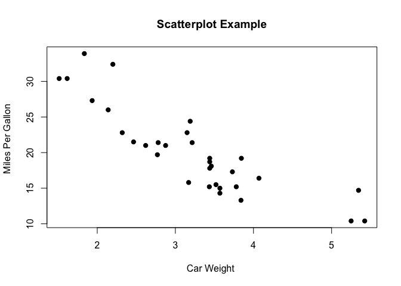

```r
attach(mtcars)
plot(wt, mpg, main="Scatterplot Example",
   xlab="Car Weight ", ylab="Miles Per Gallon ", pch=19)
```

- Basic Scatterplot Matrix

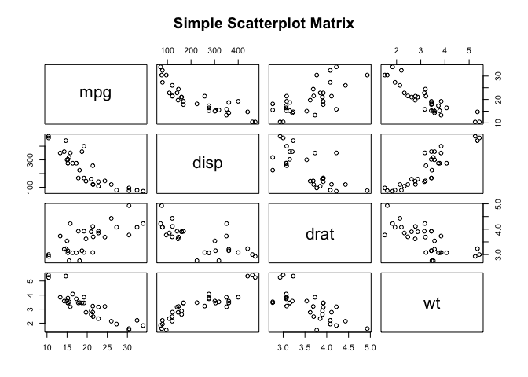

```r
pairs(~mpg+disp+drat+wt,data=mtcars,
   main="Simple Scatterplot Matrix")
```

- Barplot

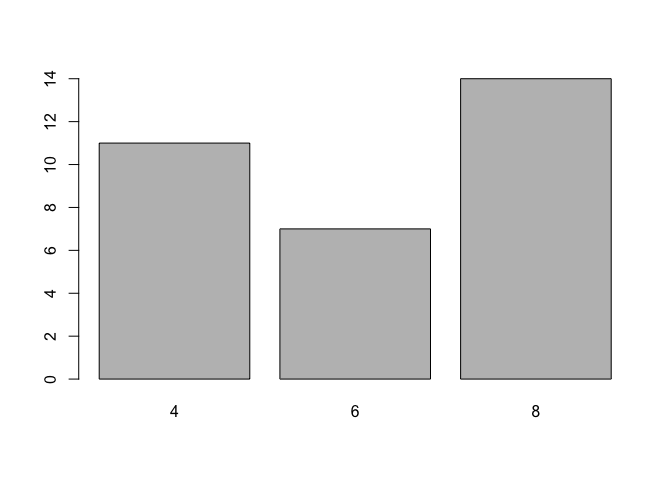

```r
tab <- table(mtcars[,c("cyl")])
barplot(tab)
```

- Piechart

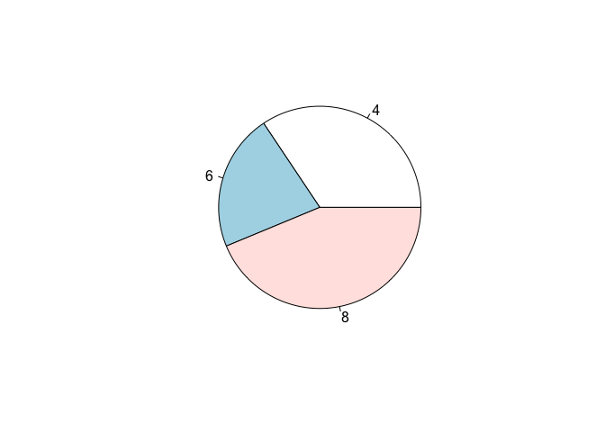

```r
pie(tab)
```

## 1.19 Exercises

1. The data.frame `VADeaths` contains the death rates per 1000 in Virginia (US) in 1940
   - The death rates are measured per 1000 population per year. They are cross-classified by age group (rows) and population group (columns). The age groups are: 50–54, 55–59, 60–64, 65–69, 70–74 and the population groups are Rural/Male, Rural/Female, Urban/Male and Urban/Female.

```r
VADeaths
```

```
##       Rural Male Rural Female Urban Male Urban Female
## 50-54       11.7          8.7       15.4          8.4
## 55-59       18.1         11.7       24.3         13.6
## 60-64       26.9         20.3       37.0         19.3
## 65-69       41.0         30.9       54.6         35.1
## 70-74       66.0         54.3       71.1         50.0
```

- Compute the mean for each age group.
  - **Result:**

```
##  50-54  55-59  60-64  65-69  70-74
## 11.050 16.925 25.875 40.400 60.350
```

- Compute the mean for each population group.
  - **Result:**

```
##   Rural Male Rural Female   Urban Male Urban Female
##        32.74        25.18        40.48        25.28
```

2. The `data.frame` `rainforest` contains several variables from different `species`

```r
library(DAAG)
rainforest
```

- Create a table of counts for each `species` and make a graphic with the results.
  - **Result:**

```
##
## Acacia mabellae      C. fraseri  Acmena smithii   B. myrtifolia
##              16              12              26              11
```

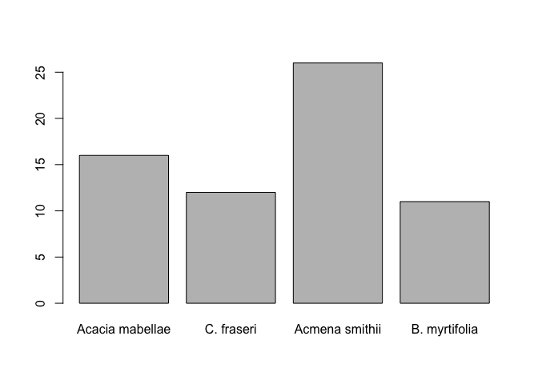

3. The `Acmena` `data.frame` is created from `rainforest` using the function `subset`.
- Plot the relationship between the wood biomass (`wood`) and the diameter of the breast height (`dbh`). Use also a logarithm scale.

```r
Acmena <- subset(rainforest, species == "Acmena smithii")
```

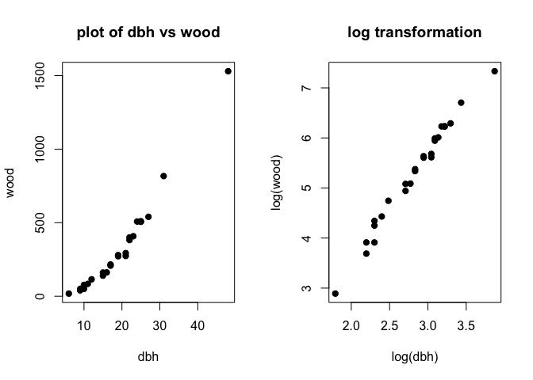

- Compute a histogram of variable `dbh` using function `hist`

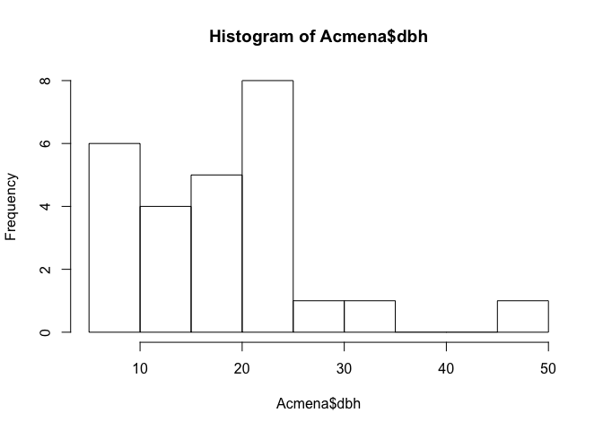

[output not shown]

- [Solutions here](http://idaejin.github.io/bcam-courses/rbasics/rbasics_sol.R)

## 1.20 Graphics

## 1.21 Basic plots and simple regression

```r
library(MASS)
data("mammals")
head(mammals)
```

```
##                    body brain
## Arctic fox        3.385  44.5
## Owl monkey        0.480  15.5
## Mountain beaver   1.350   8.1
## Cow             465.000 423.0
## Grey wolf        36.330 119.5
## Goat             27.660 115.0
```

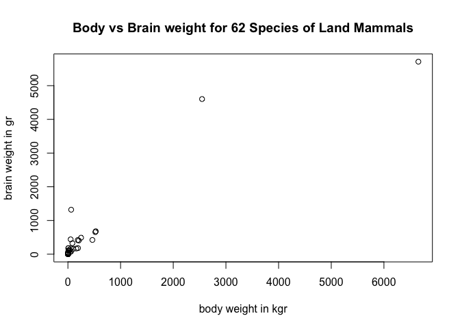

```r
attach(mammals)
species <- row.names(mammals)
x <- body
y <- brain

plot(x,y, xlab = "body weight in kgr", ylab = "brain weight in gr", main="Body vs Brain weight for 62 Species of Land Mammals") # scatterplot
```

Identify a point in the scatterplot

```r
identify(x,y,species)
```

Plot in the log scale

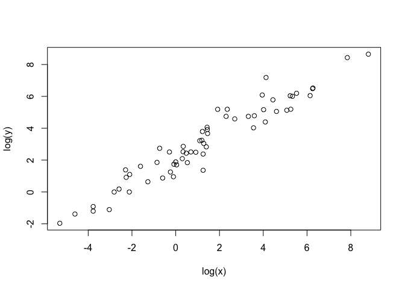

```r
plot(log(x),log(y))
```

Identify a point in the log scale scatterplot

```r
identify(log(x),log(y),species)
```

## 1.22 More plotting options

**Multiple Data Sets on One Plot**

One common task is to plot multiple data sets on the same plot. In many situations the way to do this is to create the initial plot and then add additional information to the plot. For example, to plot bivariate data the `plot` command is used to initialize and create the plot. The `points` command can then be used to add additional data sets to the plot.

```r
 x <- rnorm(10,sd=5,mean=20)
 y <- 2.5*x - 1.0 + rnorm(10,sd=9,mean=0)
 cor(x,y)
```

```
## [1] 0.9289178
```

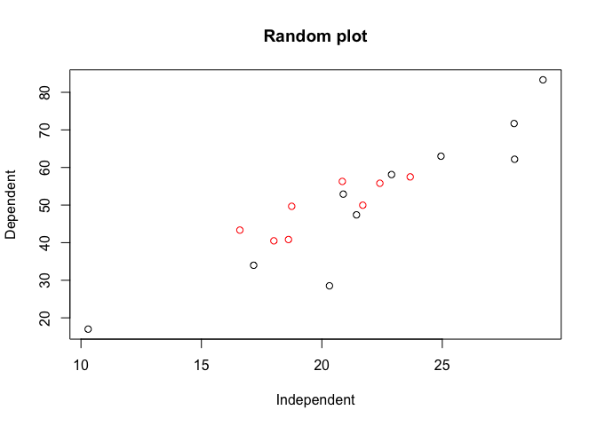

```r
 plot(x,y,xlab="Independent",ylab="Dependent",main="Random plot")
 x1 <- runif(8,15,25)
 y1 <- 2.5*x1 - 1.0 + runif(8,-6,6)
 points(x1,y1,col=2)
```

with legend and $(x_2,y_2)$ points:

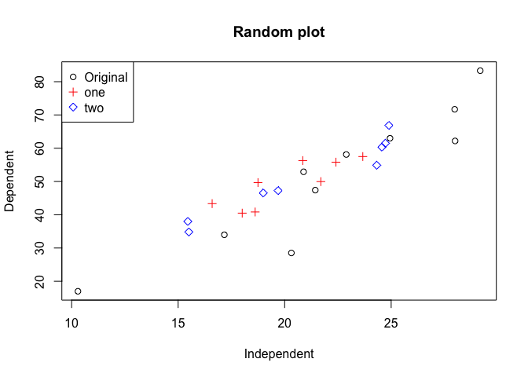

```r
x2 <- runif(8,15,25)
y2 <- 2.5*x2 - 1.0 + runif(8,-6,6)
 plot(x,y,xlab="Independent",ylab="Dependent",main="Random plot")
 points(x1,y1,col=2,pch=3)
 points(x2,y2,col=4,pch=5)
 legend("topleft",c("Original","one","two"),col=c(1,2,4),pch=c(1,3,5))
```

**Errors bars:**

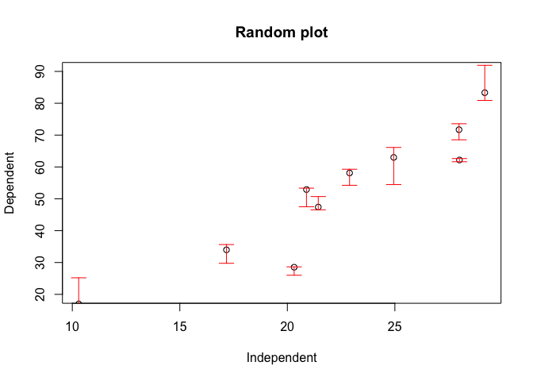

```r
plot(x,y,xlab="Independent",ylab="Dependent",main="Random plot",ylim=c(20,90))
xHigh <- x
yHigh <- y + abs(rnorm(10,sd=3.5))
xLow <- x
yLow <- y - abs(rnorm(10,sd=3.1))
arrows(xHigh,yHigh,xLow,yLow,col=2,angle=90,length=0.1,code=3)
```

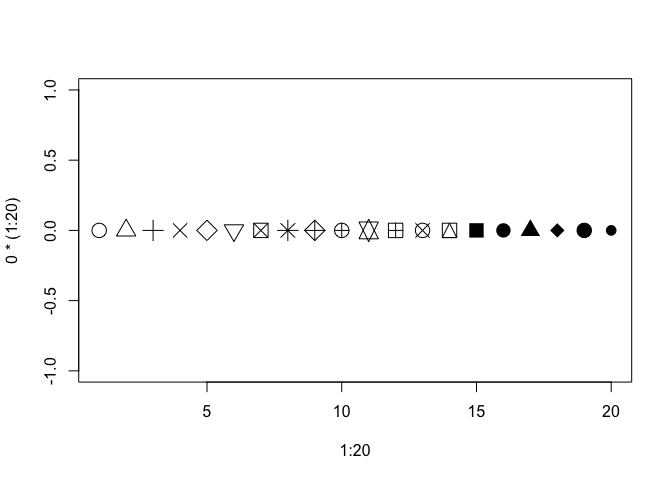

```r
plot(1:20,0*(1:20),pch=1:20,cex=2)
```

**Multiple Graphs on One Image:**

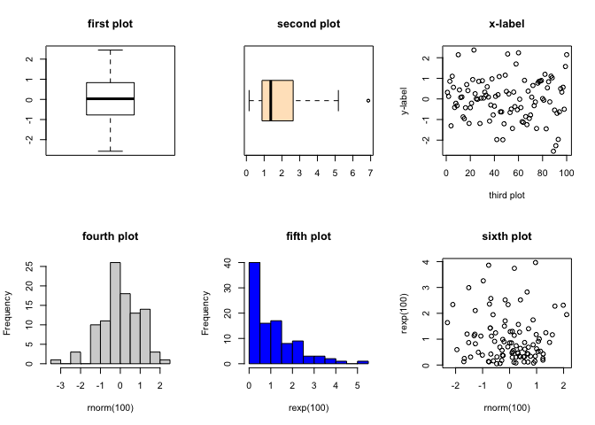

```r
 par(mfrow=c(2,3))
 boxplot(rnorm(100),main="first plot")
 boxplot(rgamma(100,2),main="second plot", horizontal=TRUE,col="bisque")
 plot(rnorm(100),xlab="third plot",
      ylab="y-label",main="x-label")
 hist(rnorm(100),main="fourth plot",col="lightgrey")
 hist(rexp(100),main="fifth plot",col="blue")
 plot(rnorm(100),rexp(100),main="sixth plot")
```

**Pairwise relatioships**

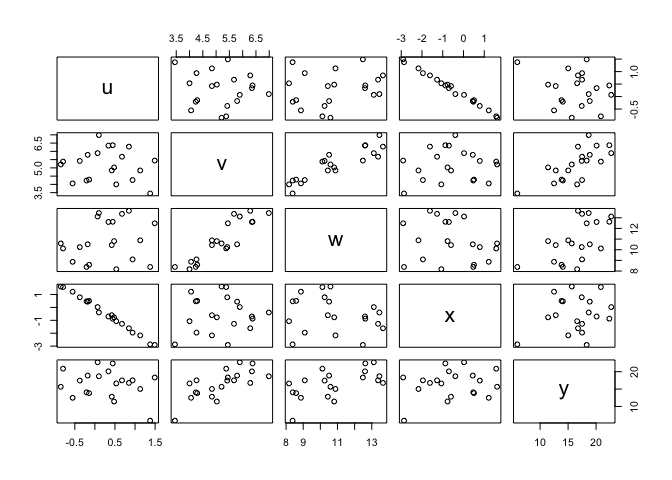

```r
uData <- rnorm(20)
vData <- rnorm(20,mean=5)
wData <- uData + 2*vData + rnorm(20,sd=0.5)
xData <- -2*uData+rnorm(20,sd=0.1)
yData <- 3*vData+rnorm(20,sd=2.5)
d <- data.frame(u=uData,v=vData,w=wData,x=xData,y=yData)
pairs(d)
```

**Plotting a surface**

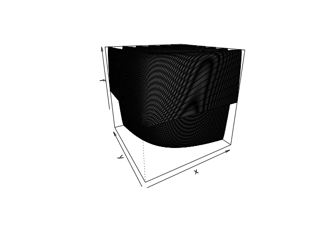

```r
x <- seq(0,2*pi,by=pi/100)
y <- x
xg <- (x*0+1) %*% t(y)
yg <- (x) %*% t(y*0+1)
f <- sin(xg*yg)
persp(x,y,f,theta=-30,phi=20)
```

## 1.23 Tables and Cross-classification

```r
library(MASS)
data(quine)
?quine
attach(quine)
table(Sex)
```

```
## Sex
##  F  M
## 80 66
```

```r
table(Sex,Age)
```

```
##    Age
## Sex F0 F1 F2 F3
##   F 10 32 19 19
##   M 17 14 21 14
```

```r
# or xtabs
xtabs(~Sex+Age,data=quine)
```

```
##    Age
## Sex F0 F1 F2 F3
##   F 10 32 19 19
##   M 17 14 21 14
```

## 1.24 Calculation of cross-classifications

```r
tapply(Days,Age,mean)
```

```
##       F0       F1       F2       F3
## 14.85185 11.15217 21.05000 19.60606
```

```r
tapply(Days,list(Sex,Age),mean)
```

```
##         F0       F1       F2       F3
## F 18.70000 12.96875 18.42105 14.00000
## M 12.58824  7.00000 23.42857 27.21429
```

```r
tapply(Days,list(Sex,Age),function(x) sqrt(var(x)/length(x)))
```

```
##         F0       F1       F2       F3
## F 4.208589 2.329892 5.299959 2.940939
## M 3.768151 1.418093 3.766122 4.569582
```

## 1.25 Qualitative data

A data sample is called qualitative, also known as categorical, if its values belong to a collection of known defined non-overlapping classes. Common examples include student letter grade (A, B, C, D or F), commercial bond rating (AAA, AAB, …) and consumer clothing shoe sizes (1, 2, 3, …).

The tutorials in this section are based on an R built-in data frame named painters. It is a compilation of technical information of a few eighteenth century classical painters. The data set belongs to the MASS package, and has to be pre-loaded into the R workspace prior to its use.

```r
library(MASS)
painters
```

```r
head(painters)
```

```
##               Composition Drawing Colour Expression School
## Da Udine               10       8     16          3      A
## Da Vinci               15      16      4         14      A
## Del Piombo              8      13     16          7      A
## Del Sarto              12      16      9          8      A
## Fr. Penni               0      15      8          0      A
## Guilio Romano          15      16      4         14      A
```

The last `School` column contains the information of school classification of the painters. The schools are named as A, B, …, etc, and the School variable is qualitative.

```r
painters$School
```

```
##  [1] A A A A A A A A A A B B B B B B C C C C C C D D D D D D D D D D E E E
## [36] E E E E F F F F G G G G G G G H H H H
## Levels: A B C D E F G H
```

```r
levels(painters$School)
```

```
## [1] "A" "B" "C" "D" "E" "F" "G" "H"
```

**Questions:** Find the frequency distribution of the painter schools in the data set painters.

```r
school <- painters$School
school.freq <- table(school)
school.freq
```

```
## school
##  A  B  C  D  E  F  G  H
## 10  6  6 10  7  4  7  4
```

# 2 Probability distributions

## 2.1 Binomial distribution $Bin(n,p)$

The binomial distribution is a discrete probability distribution. It describes the outcome of $n$ independent trials in an experiment. Each trial is assumed to have only two outcomes, either success or failure. If the probability of a successful trial is $p$, then the probability of having $k$ successful outcomes in an experiment of $n$ independent trials is given by the **probability mass function**:.

$$f(k,n,p) = \mbox{Pr}(X=k)=\binom{n}{k} p^k (1-p)^{n-k}, \quad k=0,1,2,...,n$$

The **cumulative distribution function** can be expressed as:

$$F(k;n,p) = \mbox{Pr}(X\leq k) = \sum_{i=0}^{k}\binom{n}{i} p^i (1-p)^{n-i}$$

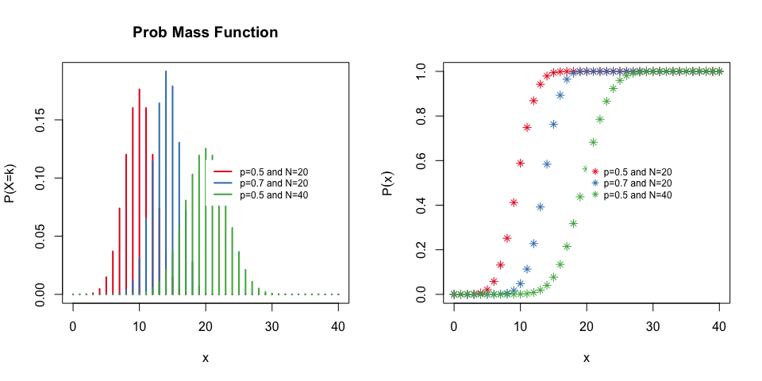

with *mean* $np$ and *variance* $np(1-p)$.

**Question:**

Suppose there are twelve multiple choice questions in an Maths class quiz. Each question has five possible answers, and only one of them is correct. Find the probability of having four or less correct answers if a student attempts to answer every question at random.

What is the probability of 2 or 3 questions answered correctly?

**Question:**

Suppose company A manufactures a product B which have probability 0.005 of being defective. Suppose product B are shipped in cartons containing 25 B items. What is the probability that a randomly chosen carton contains exactly one defective product? What is the probability that a randomly chosen carton contains no more than one defective widgit?

## 2.2 Poisson distribution $Pois(\lambda)$

The Poisson distribution is the probability distribution of independent event occurrences in an interval. If $\lambda$ is the mean occurrence per interval, then the probability of having $k$ occurrences within a given interval is the probability mass function given by:

$$\mbox{Pr}(\mbox{$k$ events in interval}) = \frac{\lambda^k e^{-\lambda}}{k!}$$

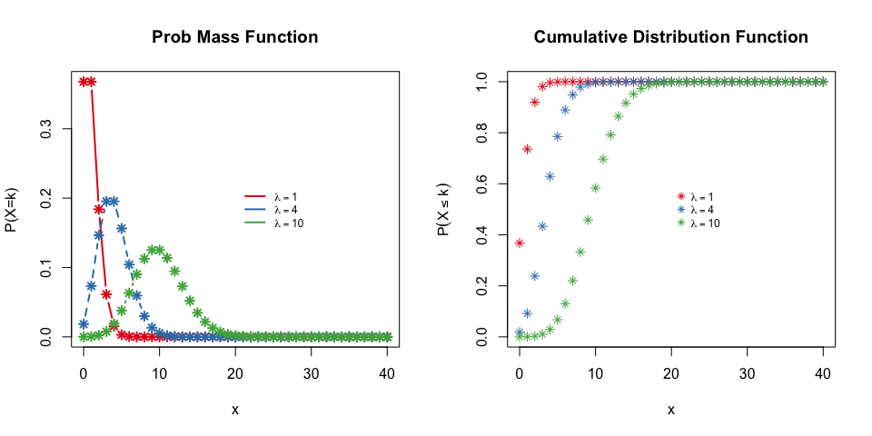

**Question:**

Suppose the number of individual plants of a given species we expect to find in a one meter square quadrat follows the Poisson distribution with mean $\lambda= 10$. Find the probability of finding exactly $12$ individuals.

**Question:**

If there are twelve cars crossing a bridge per minute on average, find the probability of having seventeen or more cars crossing the bridge in a particular minute.

## 2.3 Aproximation of Binomial as Poisson

**Example**

Five percent (5%) of Christmas tree light bulbs manufactured by a company are defective. The company’s Quality Control Manager is quite concerned and therefore randomly samples 100 bulbs coming off of the assembly line. Let X denote the number in the sample that are defective. What is the probability that the sample contains at most three defective bulbs?

```r
p = 0.05
k = 3
n = 100
pbinom(k,size=n,prob=p)
```

```
## [1] 0.2578387
```

It can be demonstrated that the Binomial distribution can be approximated with the Poisson probability mass function when $n$ is large. Using the Poisson distribution, the mean $\lambda = np$

```r
lambda <- n*p
sum(dpois(0:3,lambda))
```

```
## [1] 0.2650259
```

It is important to keep in mind that the Poisson approximation to the binomial distribution works well only when $n$ is large and $p$ is small. In general, the approximation works well if $n \geq 20$ and $p\leq0.05$, or if $n\geq 100$ and $p\leq 0.10$.

## 2.4 Exponential distribution $Exp(\lambda)$

The exponential distribution is the probability distribution that describes the time between events in a Poisson process, i.e. a process in which events occur continuously and independently at a constant average rate. It is a particular case of the gamma distribution. It is the continuous analogue of the geometric distribution, and it has the key property of being memoryless. In addition to being used for the analysis of Poisson processes, it is found in various other contexts.

The probability density function (pdf) of an exponential distribution as
$$f(x;\lambda) = \lambda \exp(-\lambda x)$$

where $\lambda>0$ is the event rate (also known as rate parameter, arrival rate, death rate, failure rate, transition rate). The exponential variable $x \in [0,\infty)$

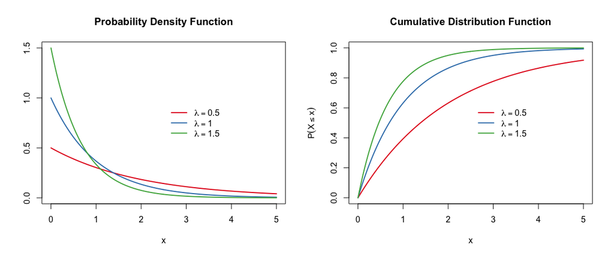

Cumulative distribution function of the exponential distribution is
$$F(x) = \mbox{Pr}(X\leq x) =
\left\{
\begin{array}{lcc}
1- e^{-\lambda x} & & x\geq 0 \\
0 & & x < 0
\end{array}
\right.$$

Mean $\mathbb{E}(X) = 1/\lambda$, and $\mathbb{V}ar(X) = 1/\lambda^2$.

**Question:**

Suppose that the amount of time one spends in a bank is exponentially distributed with mean 10 minutes, $\lambda=1/10$.

- What is the probability that a customer will spend more than 15 minutes in the bank?
- What is the probability that a customer will spend more than 15 minutes in the bank given that he is still in the bank after 10 minutes?

## 2.5 The Normal distribution $\mathcal{N}(\mu,\sigma^2)$

The probability density function of the Normal distribution is:

$$f(x | \mu,\sigma^2) = \frac{1}{\sqrt{2\sigma^2\pi}} e ^{-\frac{(x-\mu)^2}{2\sigma^2}},$$
where

- $\mu$ is the mean of the distribution (also the median and the mode).
- $\sigma$ is the standard deviation ($\sigma>0$).
- $\sigma^2$ is the variance.

The process to standardized Normal distribution consists in transforming the Normal variable $N(\mu,\sigma)$ to $N(0,1)$, i.e.
$$Z = \frac{X-\mu}{\sigma} \sim N(0,1)$$

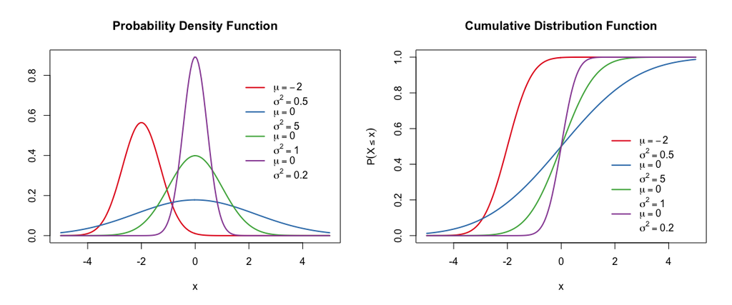

**Question:**

$X$ is a normally distributed variable with mean $\mu = 30$ and standard deviation $\sigma = 4$. Find

1. $P(x<40)$
2. $P(x>21)$
3. $P(30<x<35)$

**Question:**

Entry to a certain University is determined by a national test. The scores on this test are normally distributed with a mean of 500 and a standard deviation of 100. Tom wants to be admitted to this university and he knows that he must score better than at least 70% of the students who took the test. Tom takes the test and scores 585. Will he be admitted to this university?

# 3 Statistical Inference

We wish to test a null hypothesis ($H_0$) against an alternative hypothesis ($H_1$) using a dataset. The two hypotheses specify two statistical models for the process that produced the data. The alternative hypothesis is what we expect to be true if the null hypothesis is false. Wecannot prove that the alternative hypothesis is true but we may be able to demonstrate that the alternative is much more plausible than the null hypothesis given the data. This demonstration is usually expressed in terms of a probability (a P-value) quantifying the strength of the evidence against the null hypothesis in favor of the alternative.

We ask whether the data appear to be consistent with the null hypothesis or whether it is unlikely that we would obtain data of this kind if the null hypothesis were true, assuming that at least one of the two hypotheses is true. We address this question by calculating the value of a test statistic, i.e., a particular real-valued function of the data. To decide whether the value of the test statistic is consistent with the null hypothesis, we need to know what sampling variability to expect in our test statistic if the null hypothesis is true. In other words, we need to know the null distribution, the distribution of the test statistic when the null hypothesis is true. In many applications, the test statistic is defined so that its null distribution is a “named” distribution for which tables are widely accessible; e.g., the standard normal distribution, the Binomial distribution with n = 100 and p = 1/2, the t distribution with 4 degrees of freedom, the chi-square distribution with 23 degrees of freedom, the F distribution with 2 and 20 degrees of freedom.

Now, given the value of the test statistic (a number), and the null distribution of the test statistic (a theoretical distribution usually represented by a probability density), we want to see whether the test statistic is in the middle of the distribution (consistent with the null hypothesis) or out in a tail of the distribution (making the alternative hypothesis seem more plausible). Sometimes we will want to consider the right-hand tail, sometimes the left-hand tail, and sometimes both tails, depending on how the test statistic and alternative hypothesis are defined. Suppose that large positive values of the test statistic seem more plausible under the alternative hypothesis than under the null hypothesis. Then we want a measure of how far out our test statistic is in the right-hand tail of the null distribution. The P-value provides a measure of this distance. The P-value (in this situation) is the probability to the right of our test statistic calculated using the null distribution. The further out the test statistic is in the tail, the smaller the P-value, and the stronger the evidence against the null hypothesis in favor of the alternative. The P-value can be interpreted in terms of a hypothetical repetition of the study. Suppose the null hypothesis is true and a new dataset is obtained independently of the first dataset but using the same sampling procedure. If the new dataset is used to calculate a new value of the test statistic (same formula but new data), what is the probability that the new value will be further out in the tail (assuming a one-tailed test) than the original value? This probability is the P-value.

| $p$-value | Interpretation |
| --- | --- |
| $p> 0.10$ | No evidence against the null hypothesis. The data appear to be consistent with the null hypothesis |
| $0.05<p<0.10$ | Weak evidence against the null hypothesis in favor of the alternative |
| $0.01<p<0.05$ | Moderate evidence against the null hypothesis in favor of the alternative. |
| $0.001<p<0.01$ | Strong evidence against the null hypothesis in favor of the alternative |
| $p<0.001$ | Very strong evidence against the null hypothesis in favor of the alternative |

In using this kind of language, one should keep in mind the difference between statistical significance and practical significance. In a large study one may obtain a small P-value even though the magnitude of the effect being tested is too small to be of importance (see the discussion of power below). It is a good idea to support a P-value with a confidence interval for the parameter being tested.

## 3.1 Two sample tests

### 3.1.1 Two sample Z-test

Comparison of the means of two independent groups of samples, taken from two populations with *known* variance.

```r
sample.A = c(175, 168, 168, 190, 156, 181, 182, 175, 174, 179)
sample.B = c(185, 169, 173, 173, 188, 186, 175, 174, 179, 180)
```

$$Z=\frac{(\overline{x}_1-\overline{x}_2)-(\mu_1-\mu_2)}{\sqrt{\frac{\sigma_1^2}{n_1}+\frac{\sigma_2^2}{n_2}}}$$

Since we have the variance of the population, we must proceed with a two sample Z-test. Even in this case is not avalilable in R a function to solve the problem, but we can easily create it ourselves.

```r
z.test2sam = function(a, b, var.a, var.b){
   n.a = length(a)
   n.b = length(b)
   zeta = (mean(a) - mean(b)) / (sqrt(var.a/n.a + var.b/n.b))
   return(zeta)
}
```

To compute the $p$-value

```r
z <- z.test2sam(sample.A,sample.B,5,8.5)
pvalue2sided <- 2*pnorm(-abs(z))
pvalue2sided
```

```
## [1] 0.003430706
```

# 4 Linear models in `R` and ANOVA

[link](http://ms.mcmaster.ca/peter/s2ma3/s2ma3_0102/classnotes/notes20020328.html)

# 5 Logistic regression for the binomial distribution

# 6 Analysis of a 2-way contingency tables

# 7 Times series analysis

# 8 Survival Analysis

# 9 Multivariate Analysis

# 10 Optimization with `R`

# 11 References

- [R tutorial (http://www.cyclismo.org/tutorial/R](http://www.cyclismo.org/tutorial/R)